# Paquetes y funciones útiles para generar gráficos en R

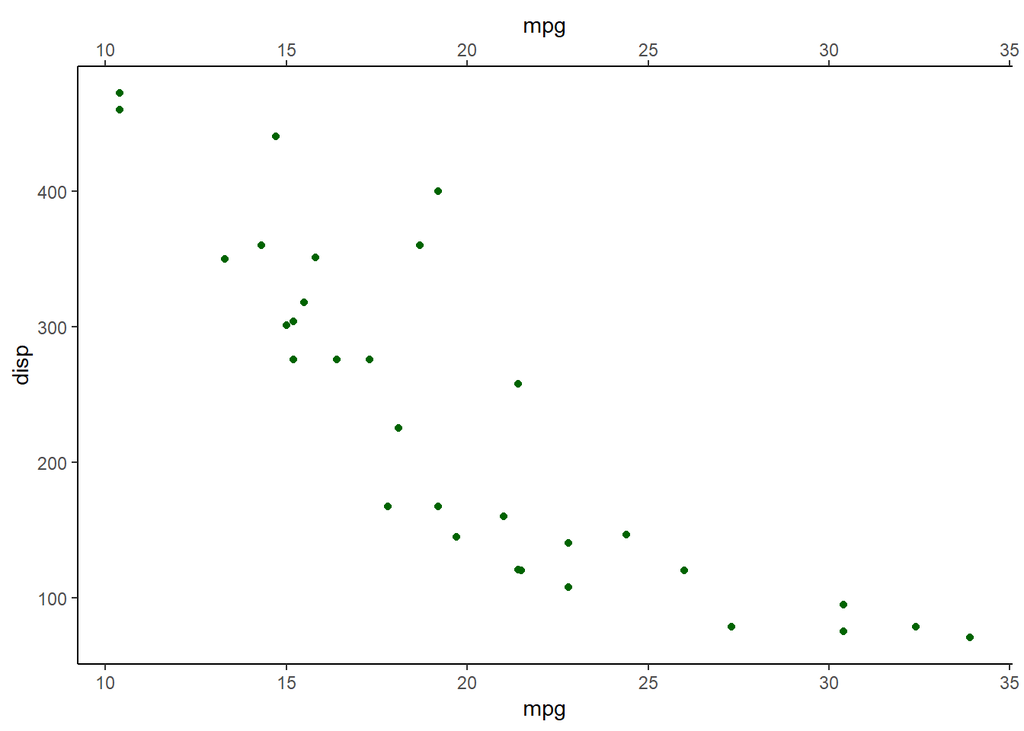

```r
p + scale_x_continuous(sec.axis = dup_axis())
```

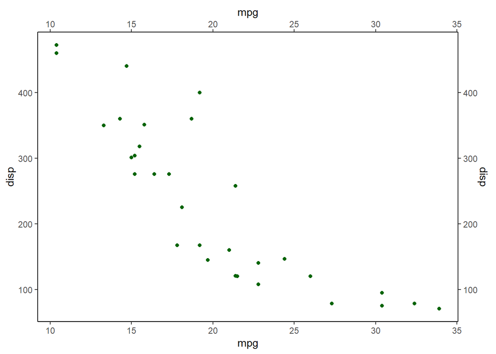

```r
p + scale_x_continuous(sec.axis = dup_axis()) +
  scale_y_continuous(sec.axis = dup_axis())
```

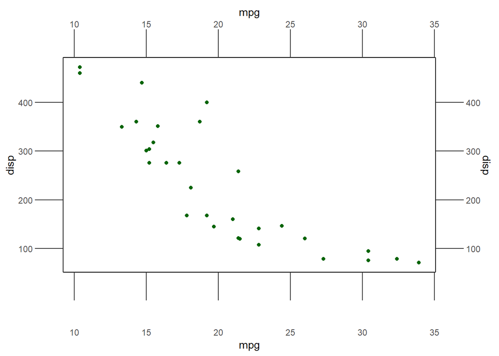

```r
p + theme(axis.ticks.length = unit(1, "cm"),
          axis.text.x = element_text(margin = margin(1, unit = "cm"))) +
  scale_x_continuous(sec.axis = dup_axis()) +
  scale_y_continuous(sec.axis = dup_axis())
```

# Paquete [{cowplot}](https://cran.r-project.org/web/packages/cowplot/)

## Función theme_nothing()

Crear un tema totalmente vacío

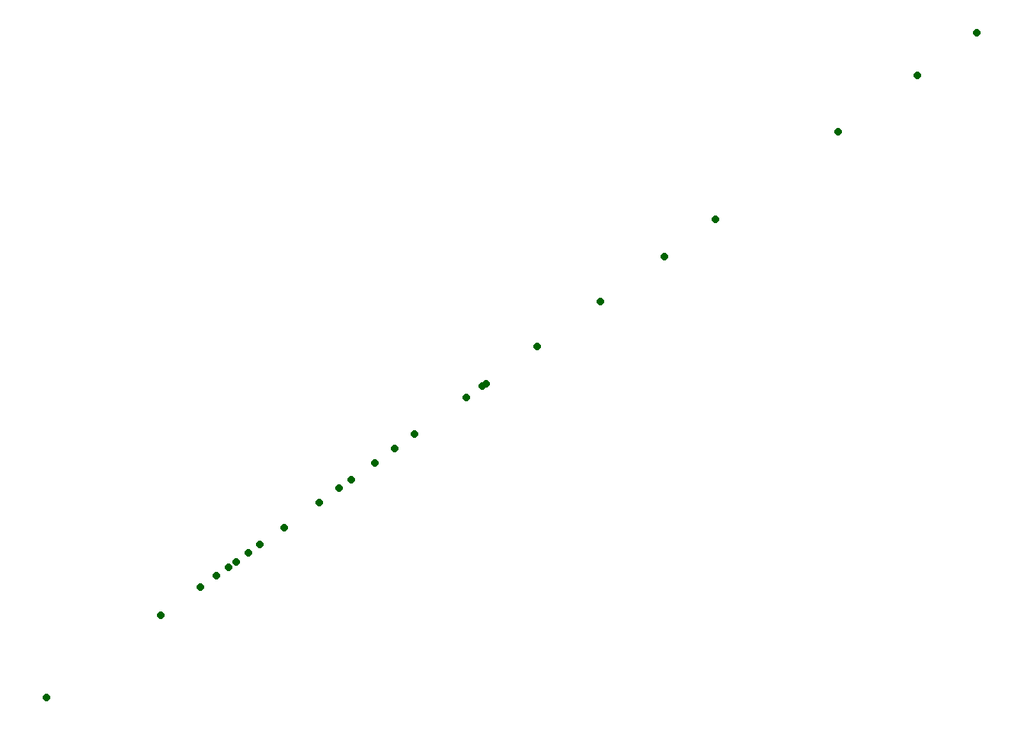

```r
# Crear un tema totalmente vacío
library(cowplot)
ggplot(mtcars, aes(mpg, mpg)) +
  geom_point(colour = "darkgreen") +
  theme_nothing()
```

## Función theme_cowplot()

Crear el tema predeterminado de cowplot

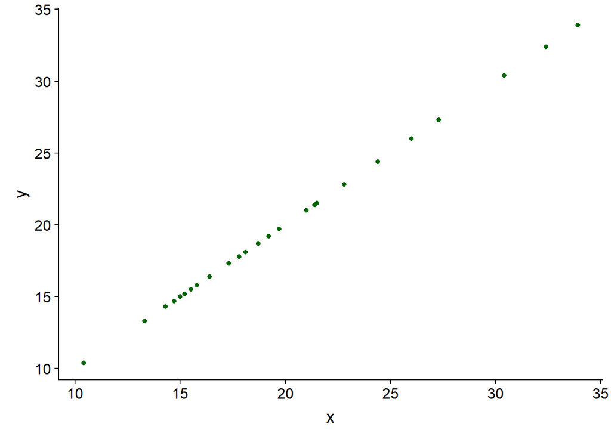

```r
# Crear el tema predeterminado de cowplot
ggplot(mtcars, aes(mpg, mpg)) +
  geom_point(colour = "darkgreen") +
  theme_cowplot() +
  labs(x="x", y="y")
```

## Función plot_grid()

Ordenar varios gráficos en una cuadrícula

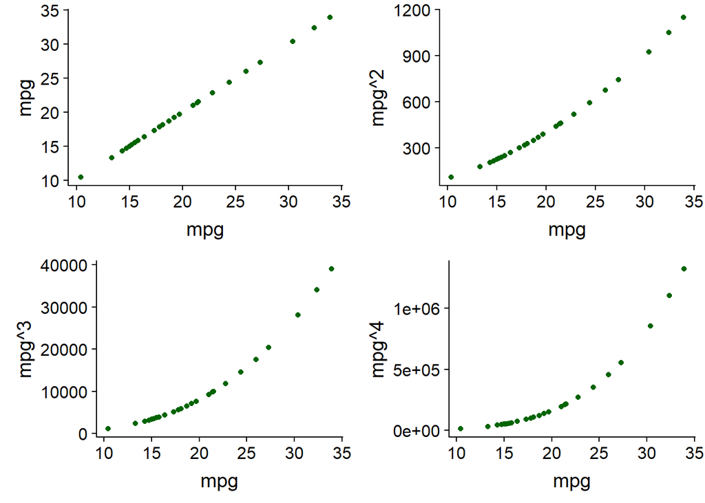

```r
# Ordenar varios gráficos en una cuadrícula
p1 <- ggplot(mtcars, aes(mpg, mpg)) +
  geom_point(colour = "darkgreen")
p2 <- ggplot(mtcars, aes(mpg, mpg^2)) +
  geom_point(colour = "darkgreen")
p3 <- ggplot(mtcars, aes(mpg, mpg^3)) +
  geom_point(colour = "darkgreen")
p4 <- ggplot(mtcars, aes(mpg, mpg^4)) +
  geom_point(colour = "darkgreen")

# Cuadrícula simple
plot_grid(p1, p2, p3, p4)
```

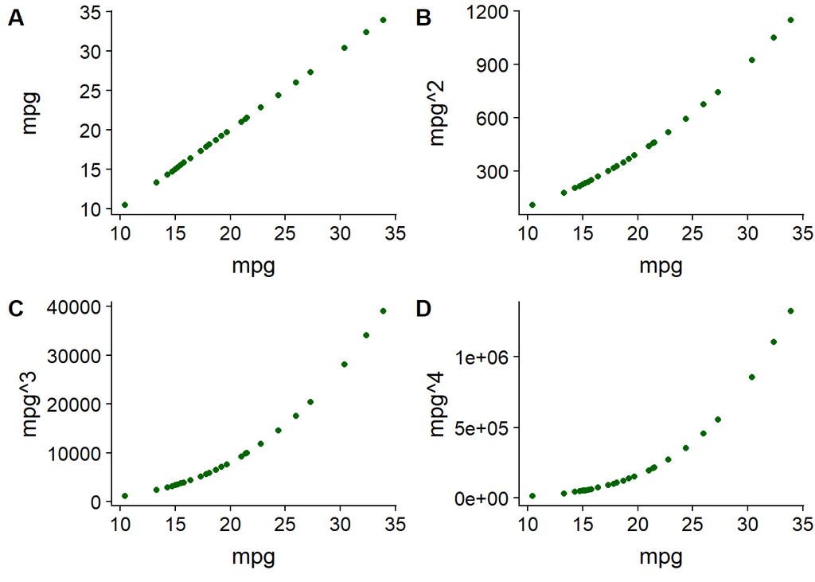

```r
# Cuadrícula simple con etiquetas y gráficos alineados tanto horizontal como vertical
plot_grid(p1, p2, p3, p4, labels=c('A', 'B', 'C', 'D'), align="hv")
```

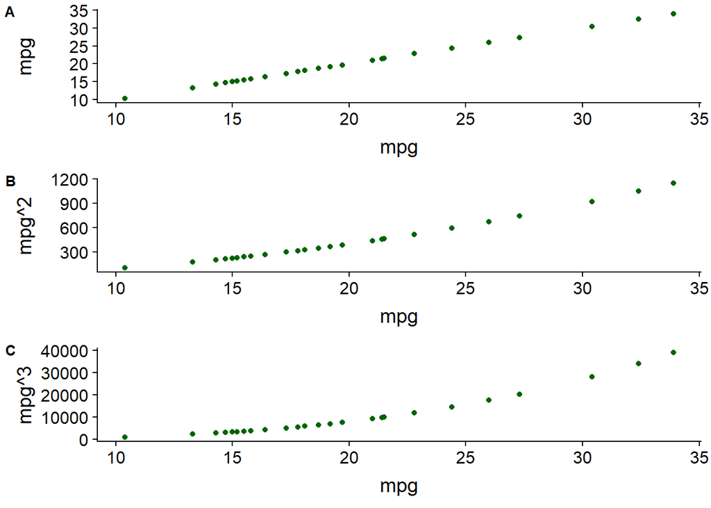

```r
# Configurar manualmente el número de filas
plot_grid(p1, p2, p3, nrow=3, labels=c('A', 'B', 'C'), label_size=10, align="v")
```

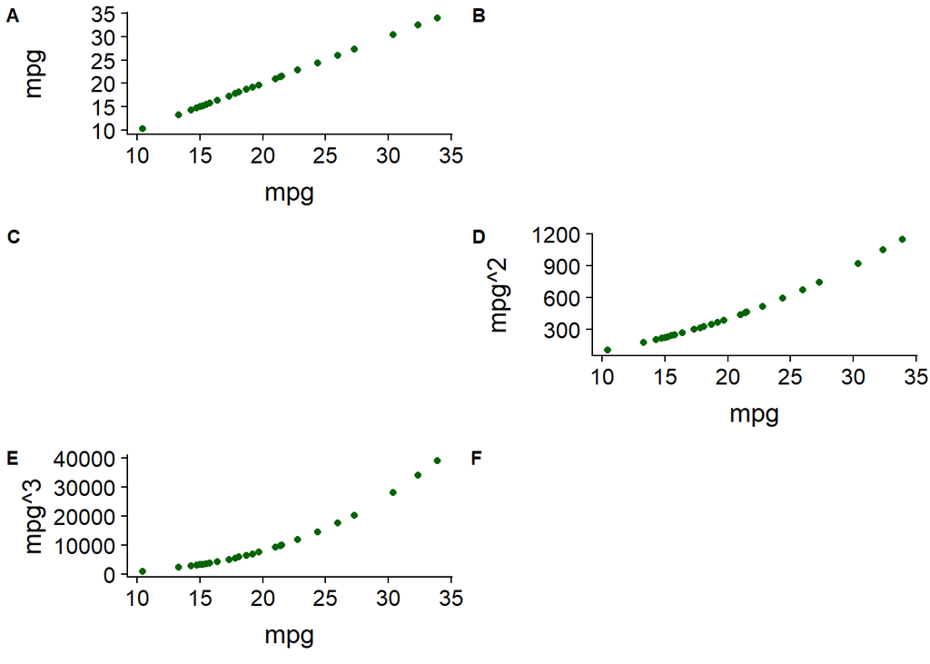

```r
# Gráficos faltantes en algunas ubicaciones de la cuadrícula
plot_grid(p1, NULL, NULL, p2, p3, NULL, ncol=2,
          labels=c('A', 'B', 'C', 'D', 'E', 'F'), label_size=10, align="v")
```

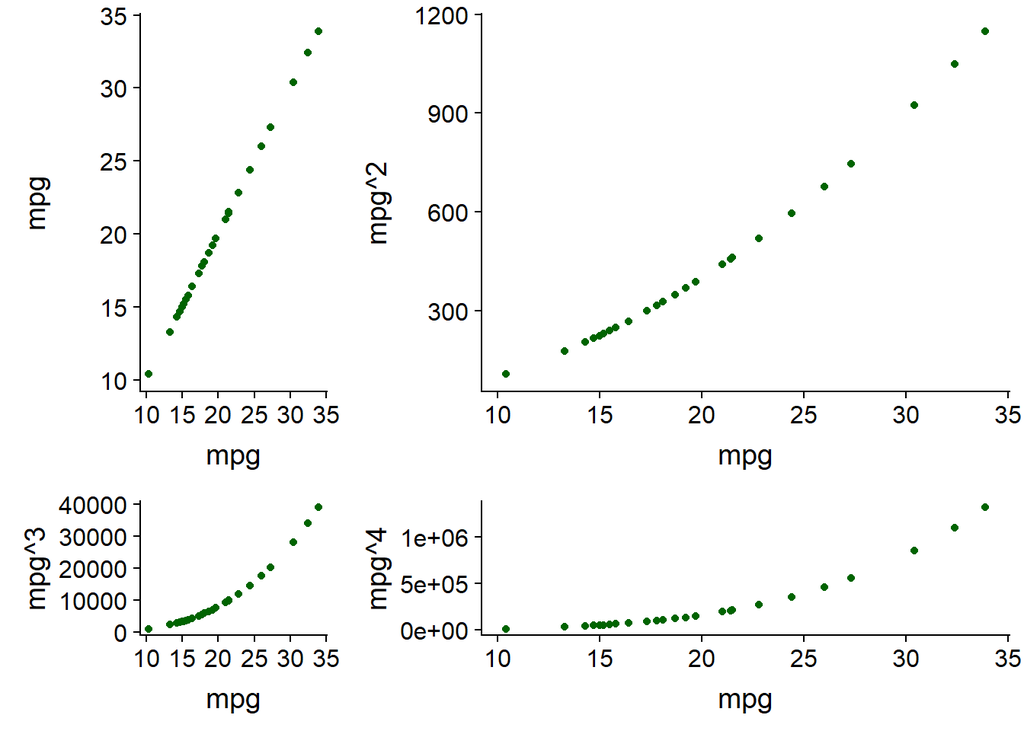

```r
# Filas y columnas de diferentes anchos/alturas.
plot_grid(p1, p2, p3, p4, align='hv', rel_heights=c(2,1), rel_widths=c(1,2))
```

## Función draw_label()

Dibujar una etiqueta de texto o expresión matemática

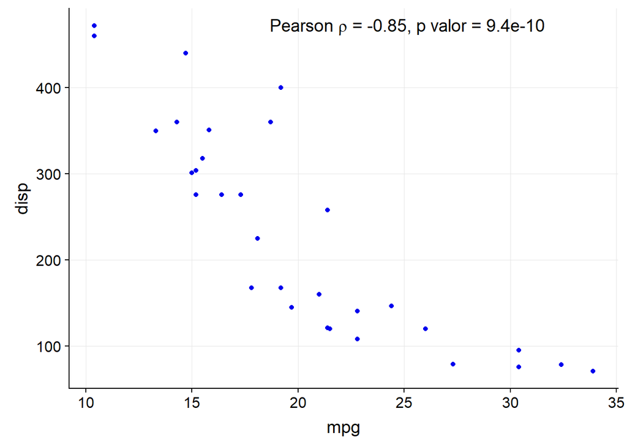

```r
# Dibujar una etiqueta de texto o expresión matemática
p <- ggplot(mtcars, aes(mpg, disp)) +
  geom_point(colour = "blue2") +
  background_grid(minor='none')
c <- cor.test(mtcars$mpg, mtcars$disp, method='pearson')
# Etiqueta
label <- substitute(paste("Pearson ", rho, " = ", estimate, ", p valor = ", pvalue),
                    list(estimate = signif(c$estimate, 2), pvalue = signif(c$p.value, 2)))
# Añadir etiqueta al gráfico
ggdraw(p) +
  draw_label(label, .65, .94)
```

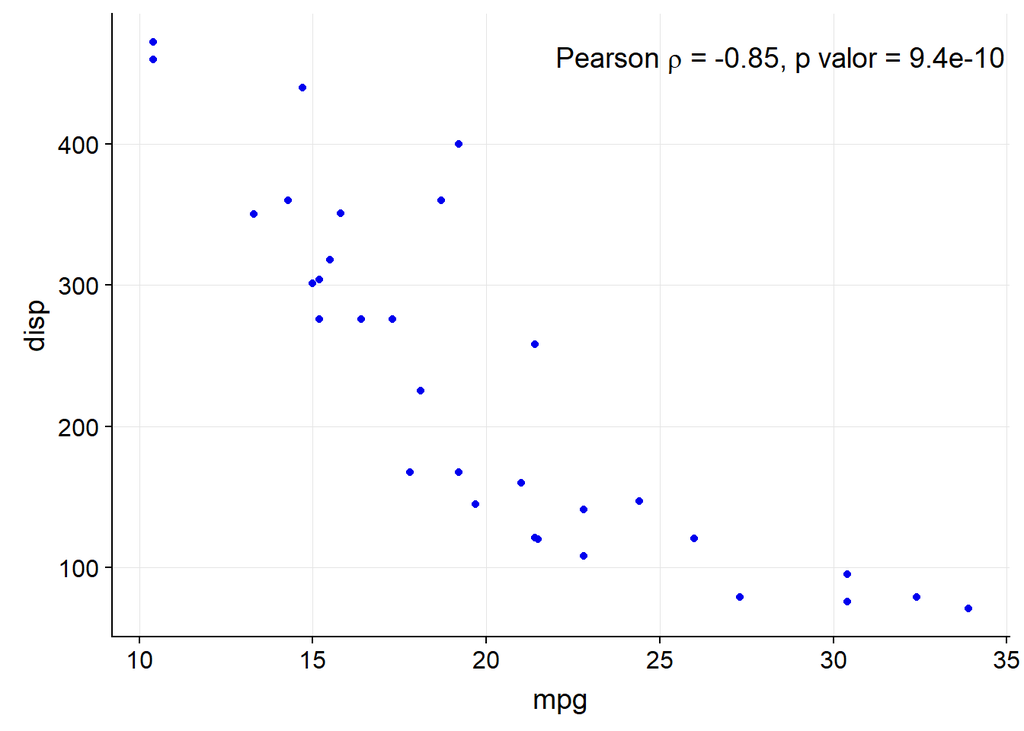

```r
# Añadir la etiqueta directamente al gráfico
p + draw_label(label, 22, 450, hjust = 0, vjust = 0)
```

## Función add_sub()

Agregar un comentario debajo de un gráfico

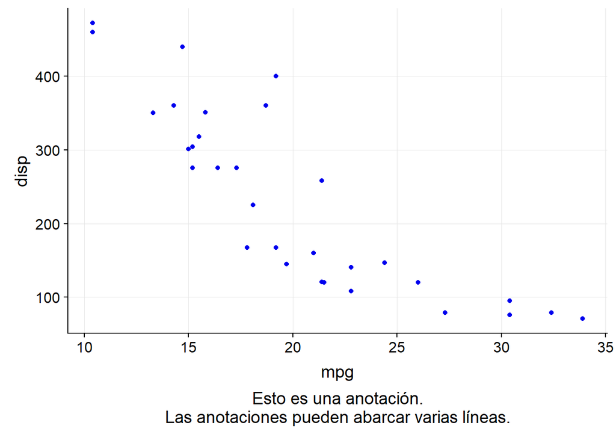

```r
# Agregar un comentario debajo de un gráfico
p1 <- ggplot(mtcars, aes(mpg, disp)) +
  geom_point(colour = "blue2") +
  background_grid(minor='none')
ggdraw(add_sub(p1, "Esto es una anotación.\nLas anotaciones pueden abarcar varias líneas."))
```

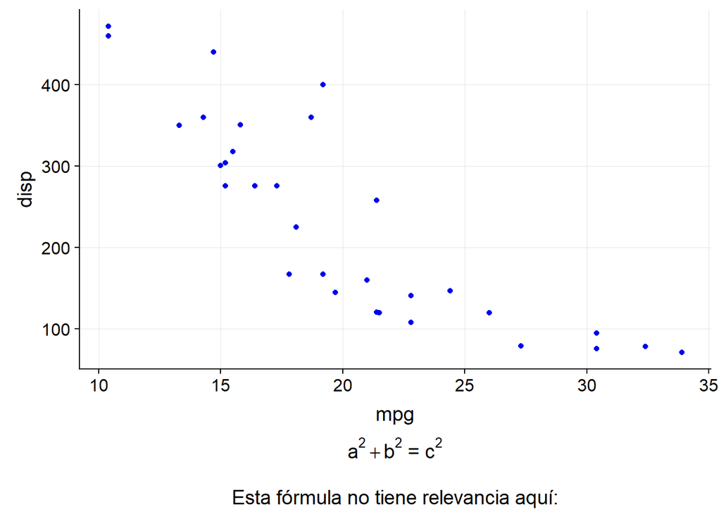

```r
# Nuevas anotaciones
p2 <- add_sub(p1, expression(paste(a^2+b^2, " = ", c^2)))
p3 <- add_sub(p2, "Esta fórmula no tiene relevancia aquí:", y  = 0, vjust = 0)
ggdraw(p3)
```

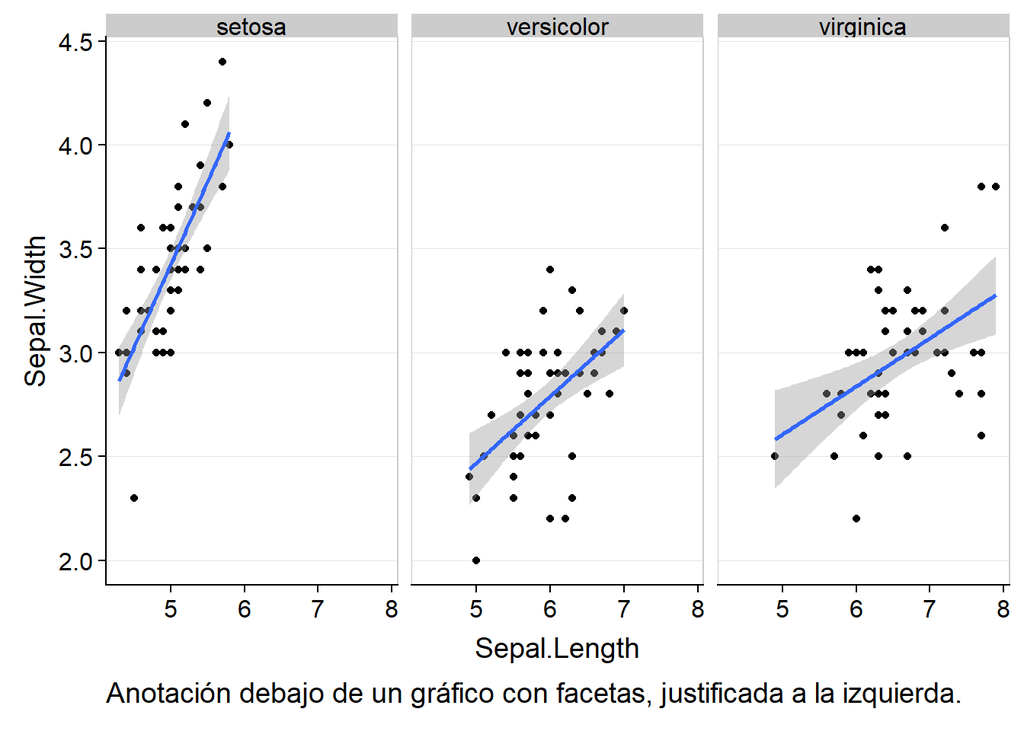

```r
# También funciona con gráficos de facetas
plot.iris <- ggplot(iris, aes(Sepal.Length, Sepal.Width)) +
  geom_point() +
  facet_grid(.~ Species) +
  stat_smooth(method = "lm") +
  background_grid(major = 'y', minor = "none") + # añadir líneas horizontales finas
  panel_border() # y un borde alrededor de cada panel
p2 <- add_sub(plot.iris, "Anotación debajo de un gráfico con facetas, justificada a la izquierda.", x = 0, hjust = 0)
ggdraw(p2)
```

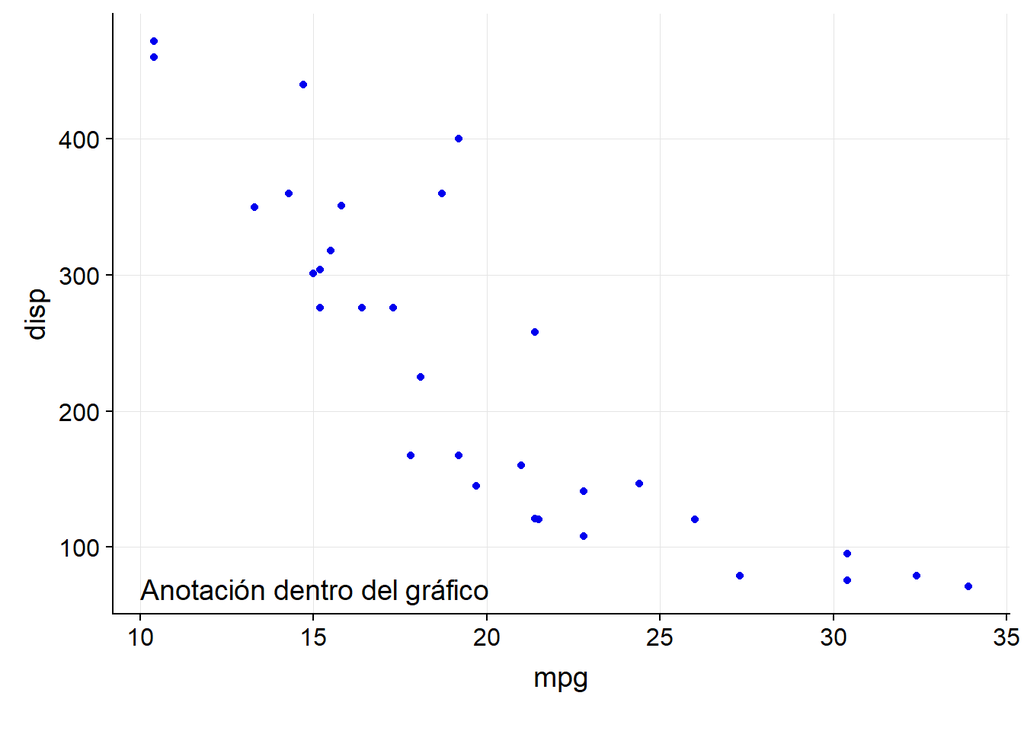

```r
# Finalmente, es posible mover la anotación dentro del gráfico si se desea.
ggdraw(add_sub(p1, "Anotación dentro del gráfico", vpadding=grid::unit(0, "lines"),
       y = 6, x = 0.03, hjust = 0))
```

# Paquete [{gapmap}](https://cran.r-project.org/web/packages/ggmap/index.html)

## Función gapmap()

Función para dibujar un mapa de calor agrupado con espacios vacíos

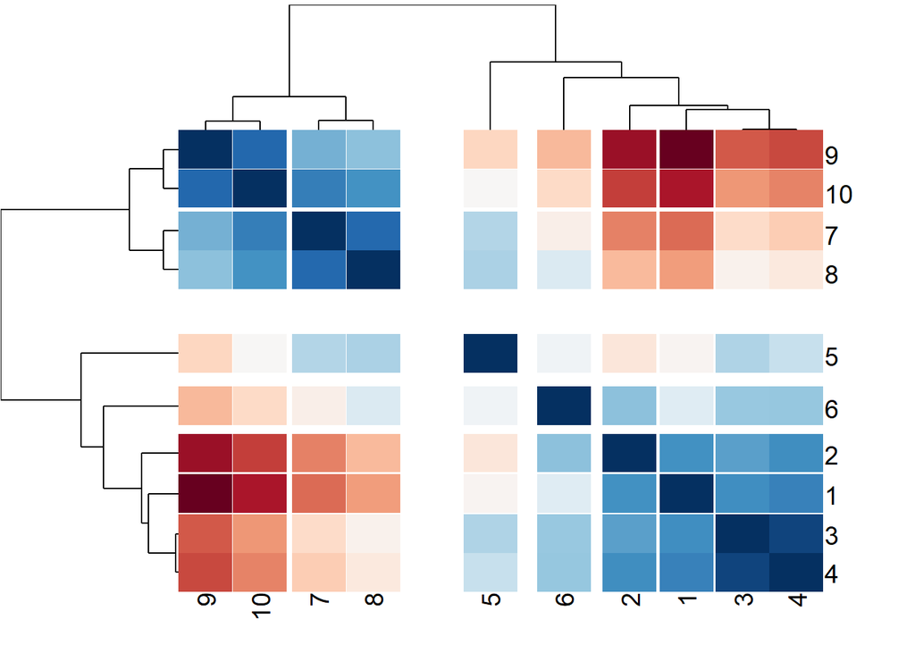

```r
# Función para dibujar un mapa de calor agrupado con espacios vacíos
require(gapmap)
set.seed(12345)
# generar una muestra de datos
x <- rnorm(10, mean=rep(1:5, each=2), sd=0.4)
y <- rnorm(10, mean=rep(c(1,2), each=5), sd=0.4)
df <- data.frame(x=x, y=y, row.names=c(1:10))
# Calcular la matriz de distancias, por defecto es la distancia euclídea
distxy <- dist(df)
# Realizar agrupamiento jerárquico, por defecto es el método complete
hc <- hclust(distxy)
dend <- as.dendrogram(hc)
# Realizar el gráfico
gapmap(m = as.matrix(distxy), d_row= rev(dend), d_col=dend)
```

# Paquete [{GGally}](https://cran.r-project.org/web/packages/GGally/index.html)

## Función scatmat()

Realiza un gráfico triangular inferior, gráficos de densidad en la diagonal principal y gráficas de dispersión por debajo.

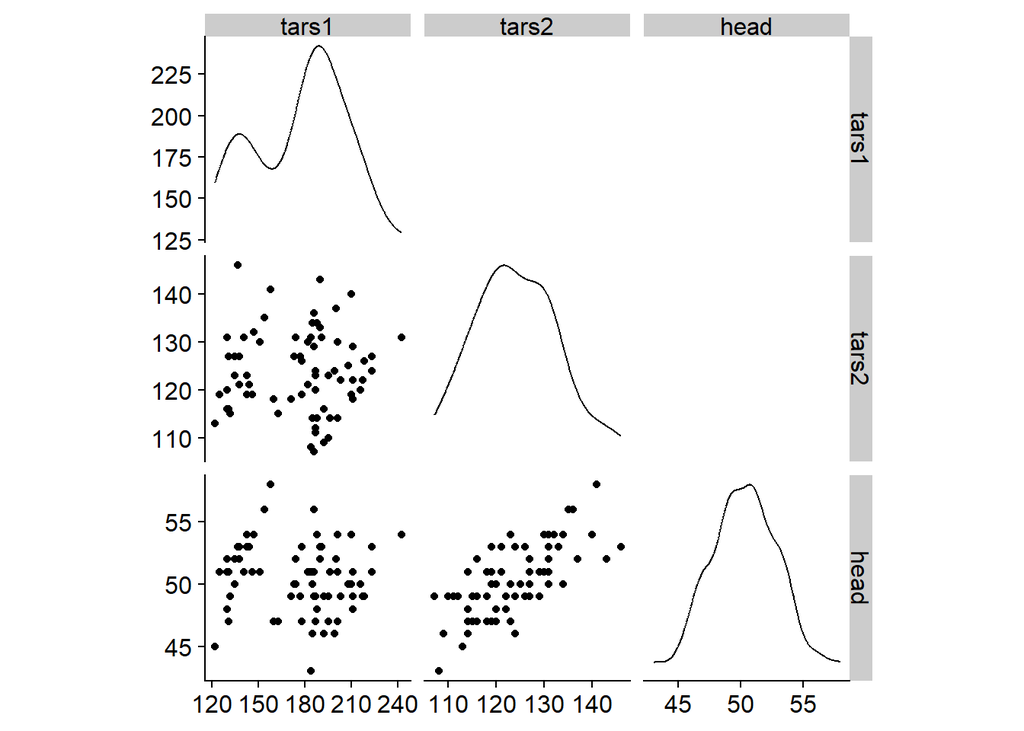

```r
require(GGally)
data(flea)
scatmat(flea, columns=2:4)
```

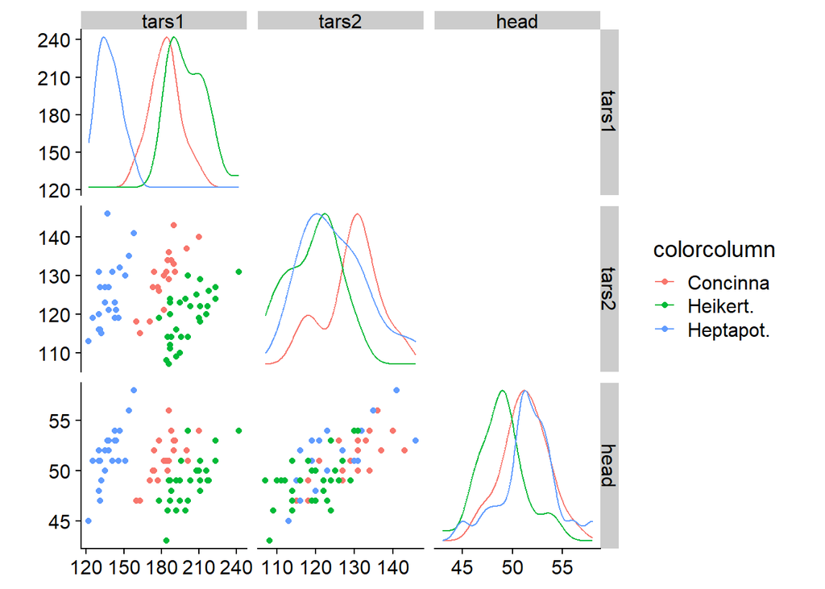

```r
# Gráfico por especie
scatmat(flea, columns= 2:4, color="species")
```

## Función glyphs()

Crea datos necesarios para generar un gráfico de glifos (es un signo grabado o, por extensión, escrito o pintado. Por ejemplo, los glifos de la escritura maya)

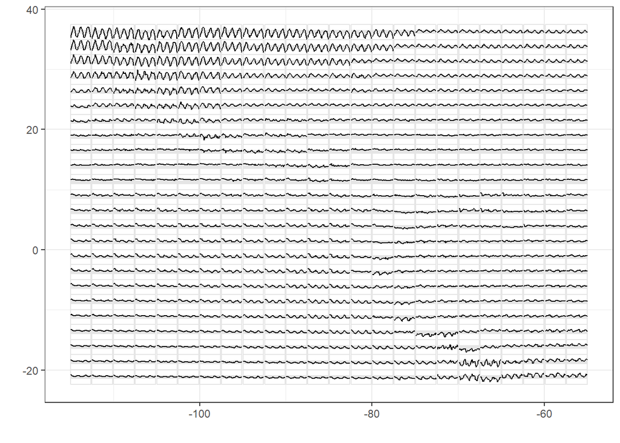

```r
data(nasa)
nasaLate <- nasa[nasa$date >= as.POSIXct("1998-01-01"), ]
temp.gly <- glyphs(nasaLate, "long", "day", "lat", "surftemp", height=2.5)

ggplot2::ggplot(temp.gly, ggplot2::aes(gx, gy, group = gid)) +
  add_ref_lines(temp.gly, color = "grey90") +
  add_ref_boxes(temp.gly, color = "grey90") +
  ggplot2::geom_path() +
  ggplot2::theme_bw() +
  ggplot2::labs(x = "", y = "")
```

## Función ggsurv()

Trazar objetos de supervivencia usando ggplot2

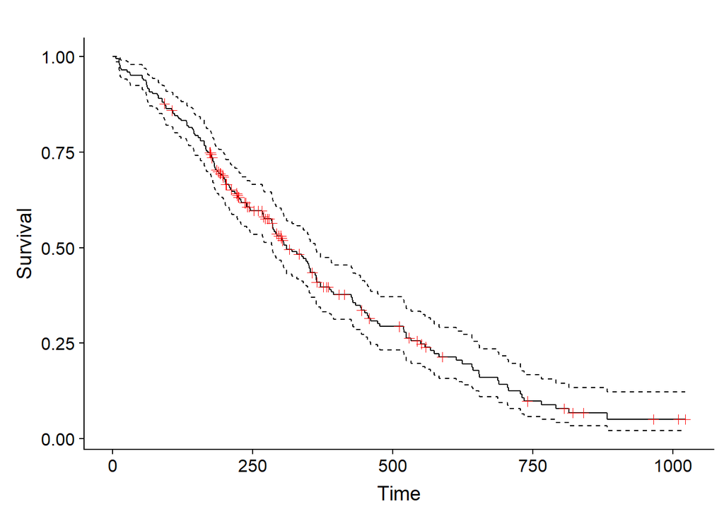

```r
require(survival)
require(scales)
data(lung, package = "survival")
sf.lung <- survival::survfit(Surv(time, status) ~ 1, data = lung)
ggsurv(sf.lung)
```

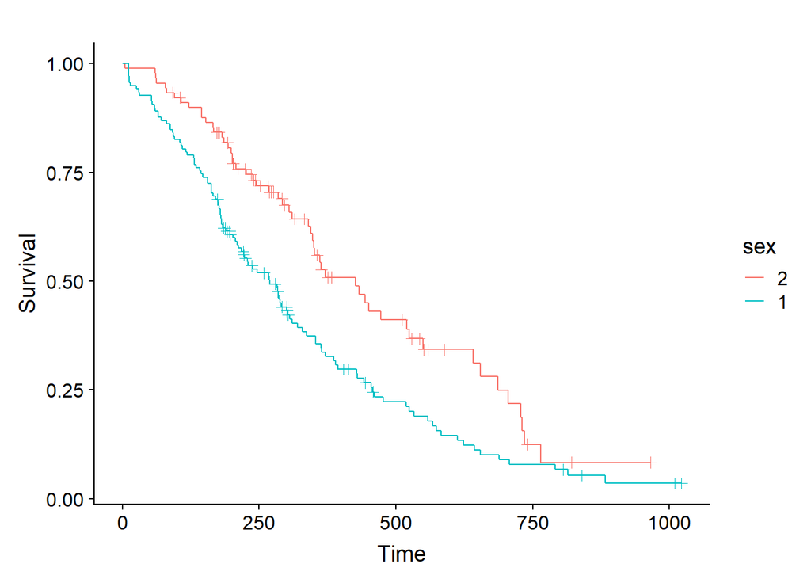

```r
# Ejemplos de varios estratos
sf.sex <- survival::survfit(Surv(time, status) ~ sex, data = lung)
pl.sex <- ggsurv(sf.sex)
pl.sex
```

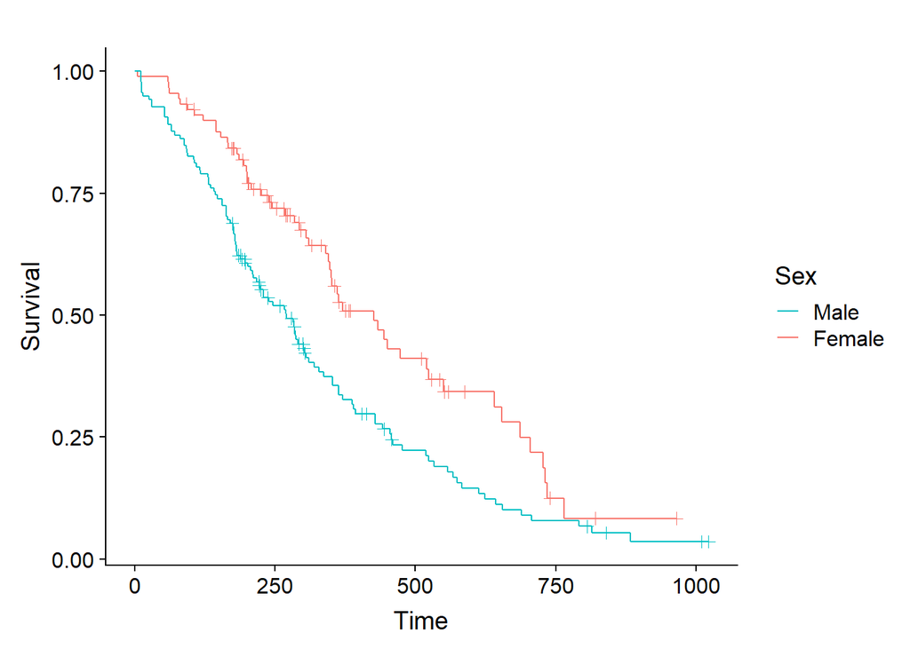

```r
# Ajustar la leyenda del ajuste ggsurv
pl.sex +
  ggplot2::guides(linetype = FALSE) +
  ggplot2::scale_colour_discrete(name = 'Sex',
                                 breaks = c(1,2),
                                 labels = c('Male', 'Female')
                                 )
```

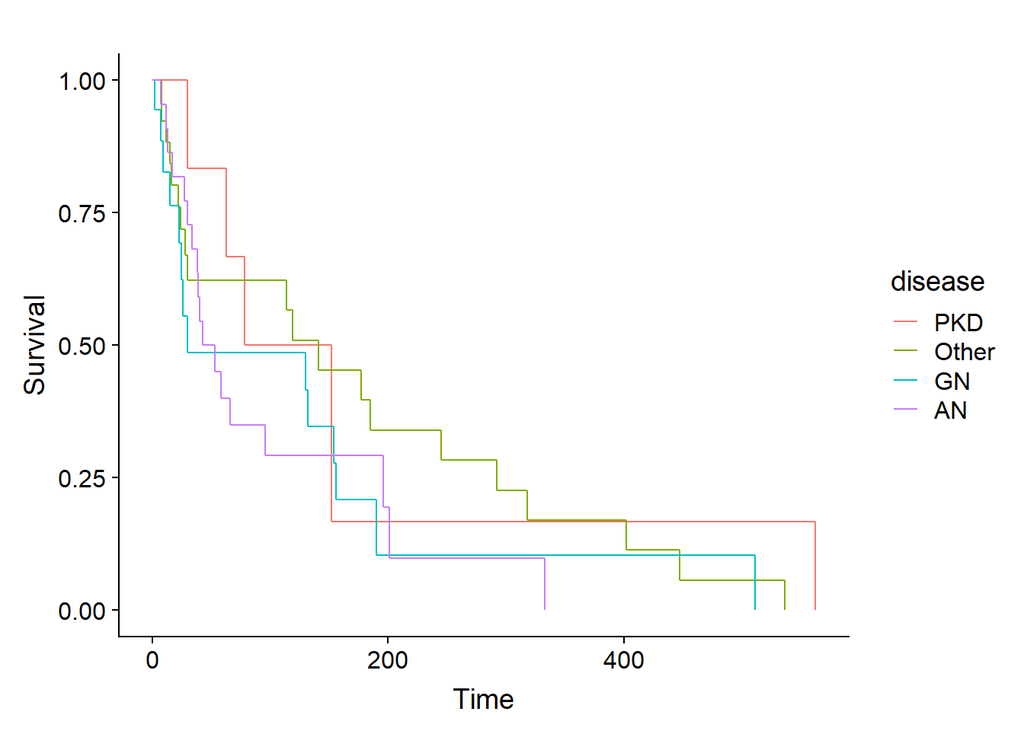

```r
# Ajustar el gráfico después de la prueba
data(kidney, package = "survival")
sf.kid <- survival::survfit(Surv(time, status) ~ disease, data = kidney)
pl.kid <- ggsurv(sf.kid, plot.cens = FALSE)
pl.kid
```

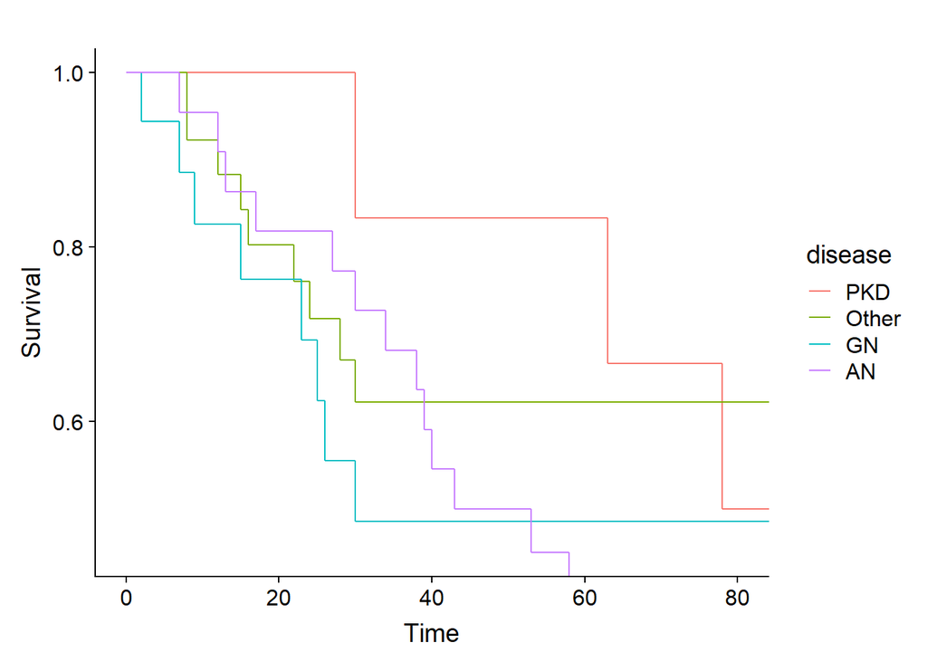

```r
# Ampliar a los primeros 80 días
pl.kid <- pl.kid + ggplot2::coord_cartesian(xlim = c(0, 80), ylim = c(0.45, 1))
pl.kid
```

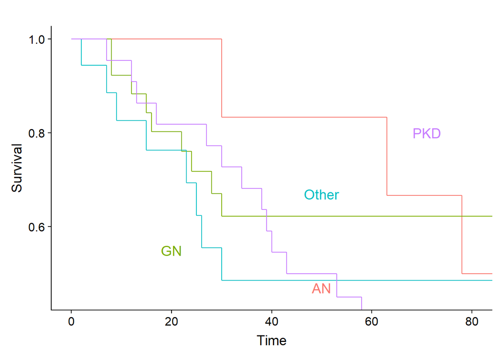

```r
# Agregar los nombres de las enfermedades al gráfico y eliminar la leyenda
col <- scales::hue_pal(h = c(0, 360) + 15,
                       c = 100,
                       l = 65,
                       h.start = 0,
                       direction = 1)(4)
pl.kid +
  ggplot2::annotate("text", label = c('AN', 'GN', 'Other', 'PKD'),
                     x = c(50, 20, 50, 71), y = c(0.47, 0.55, 0.67, 0.8), size = 5, colour = col) +
  ggplot2::guides(color = FALSE, linetype = FALSE)
```

## Función ggscatmat()

Realiza un gráfico en forma de una matriz cuadrada, esta matriz contiene los gráficos de dispersión en la triangular inferior, gráficos de densidad en la diagonal principal y las correlaciones entre pares de variables en la triangular superior.

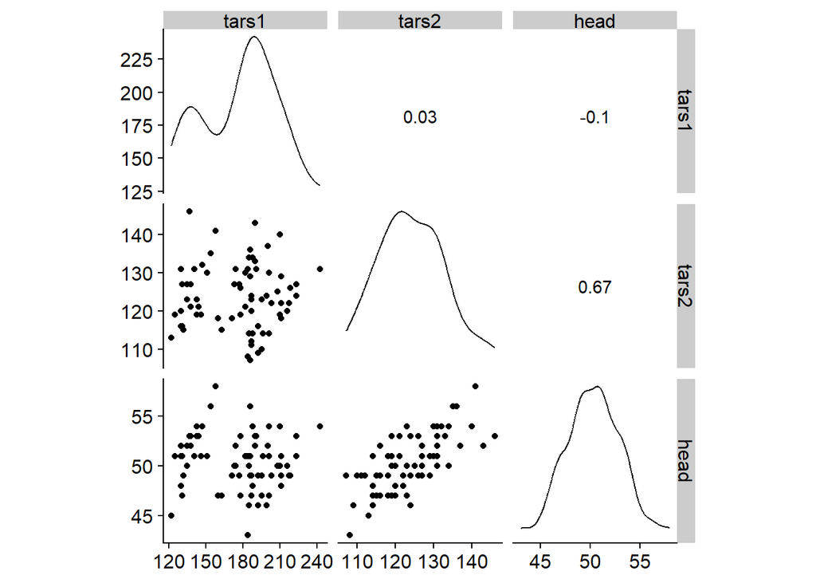

```r
require(GGally)
data(flea)
ggscatmat(flea, columns = 2:4)
```

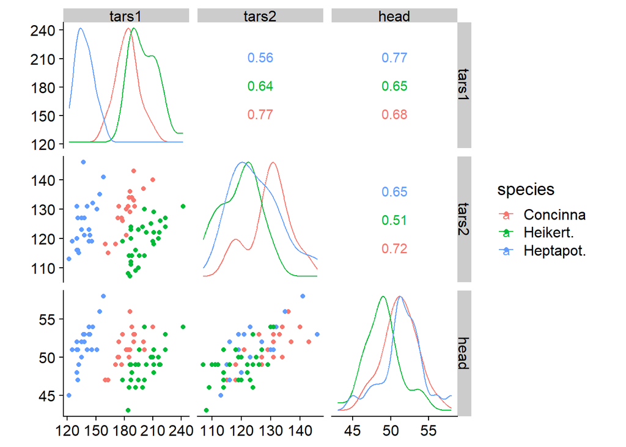

```r
# Gráfico según las especies
ggscatmat(flea, columns = 2:4, color="species")
```

## Función ggcorr()

Gráfico de una matriz de correlación con ggplot2

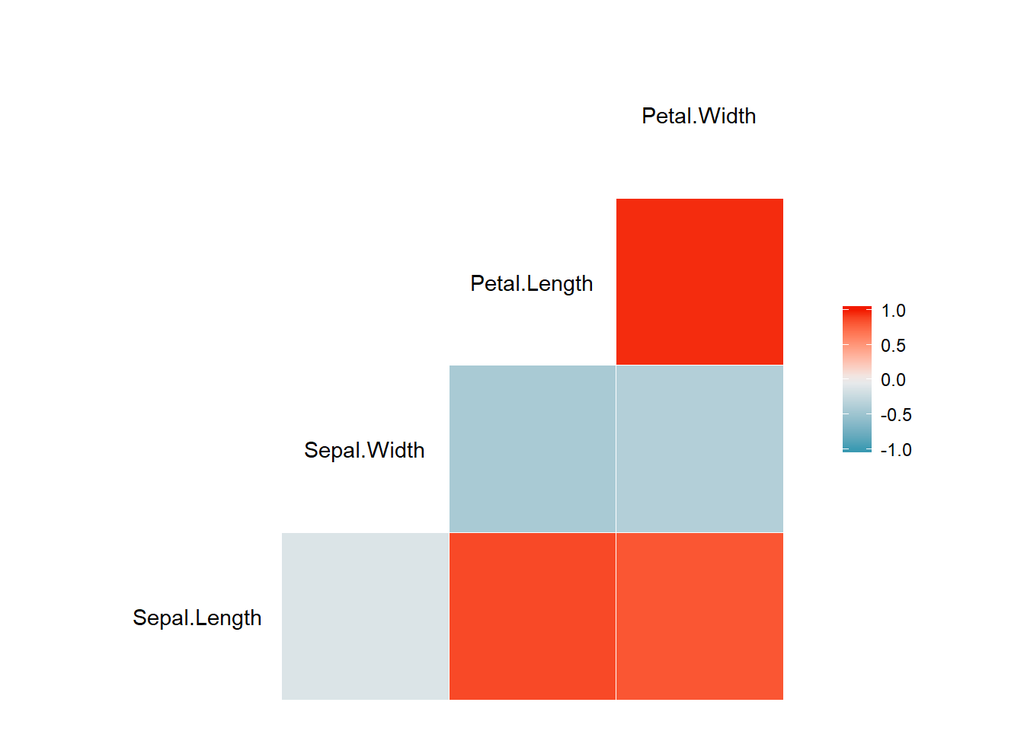

```r
data("iris")
vc.iris <- iris[, -5]
# Salida por defecto
ggcorr(vc.iris)
```

# Nota

Estas gráficas son algunas de mis prácticas para generar reportes intercativos con R Markdown, sin embargo la publicación original lo puedes en encontrar en: [ALL YOUR FIGURE ARE BELONG TO US](http://yutannihilation.github.io/allYourFigureAreBelongToUs/).